# Problem description

#### ncM

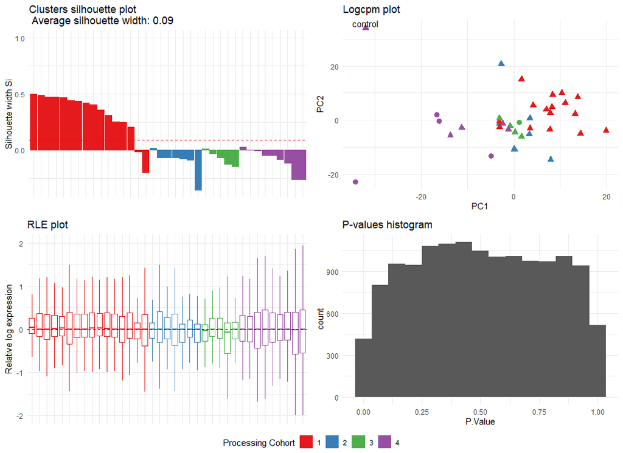

#### pDC

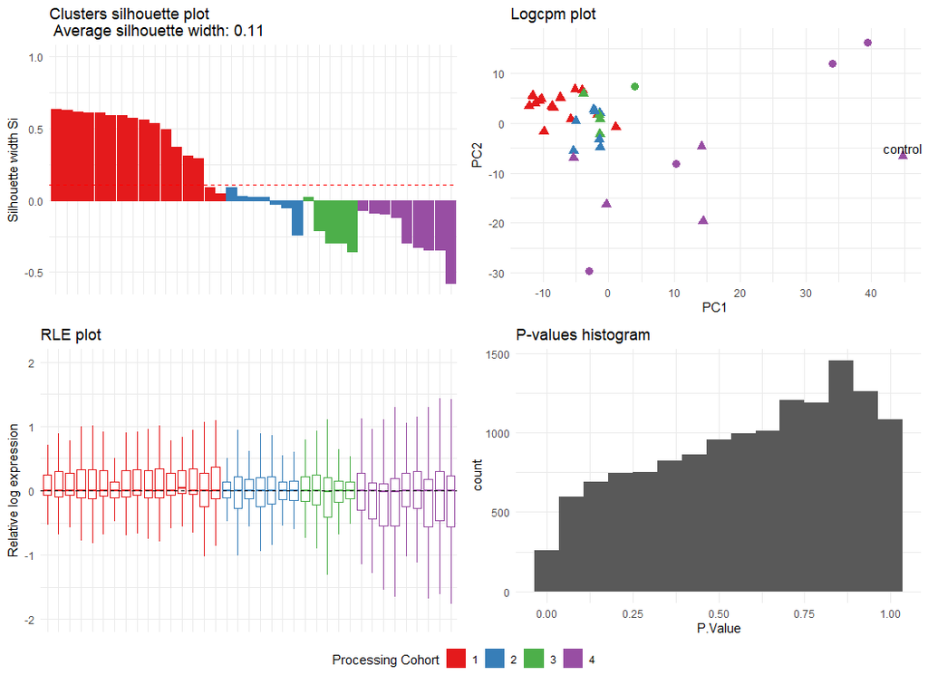

### RUV4

The RUV4 method uses the negative control genes and the information from the factor of interest (Mock treatment) to estimate the unwanted factors via EFA, for a more detail explanation check the *[technical report](https://statistics.berkeley.edu/tech-reports/820)* from *Gagnon-Bartsch et. al.*.

The RUV4 method increases the false discovery rate in the samples from T4 and NK cells, this is observed in the skewed p-values histrograms. Therefore its use to normalize datasets is not recommended.

#### B

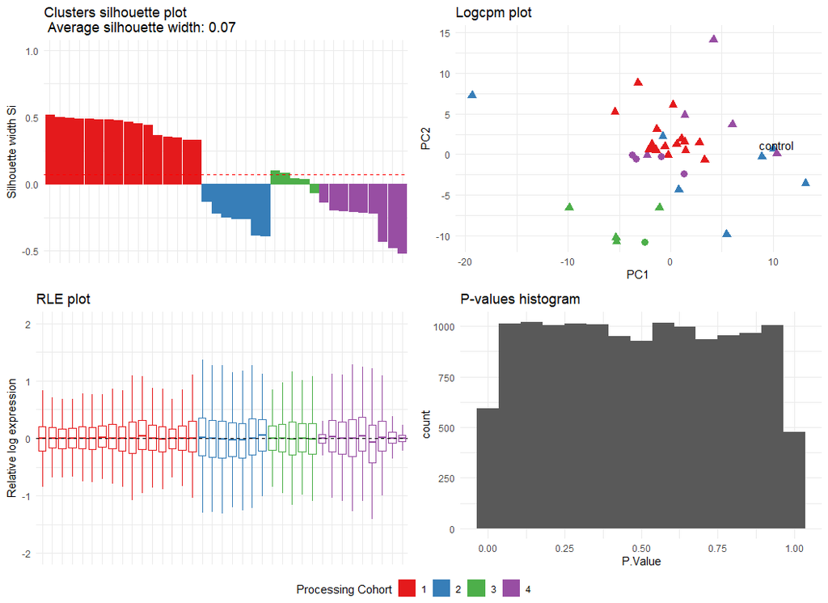

#### NK

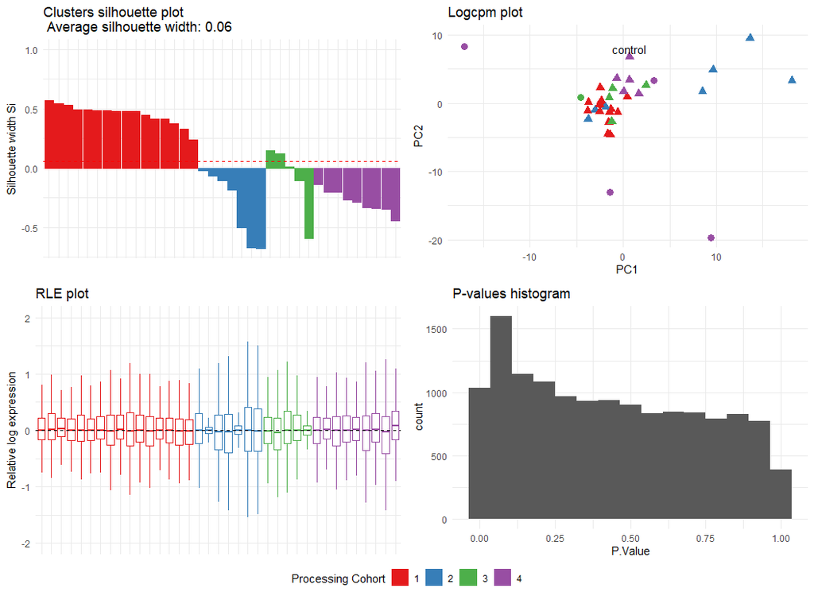

#### T4

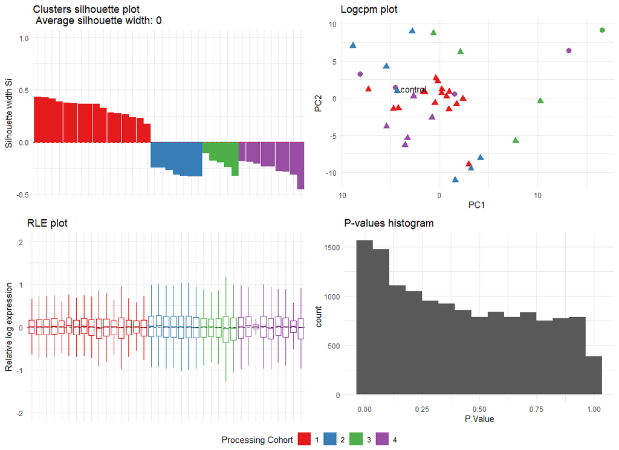

#### T8

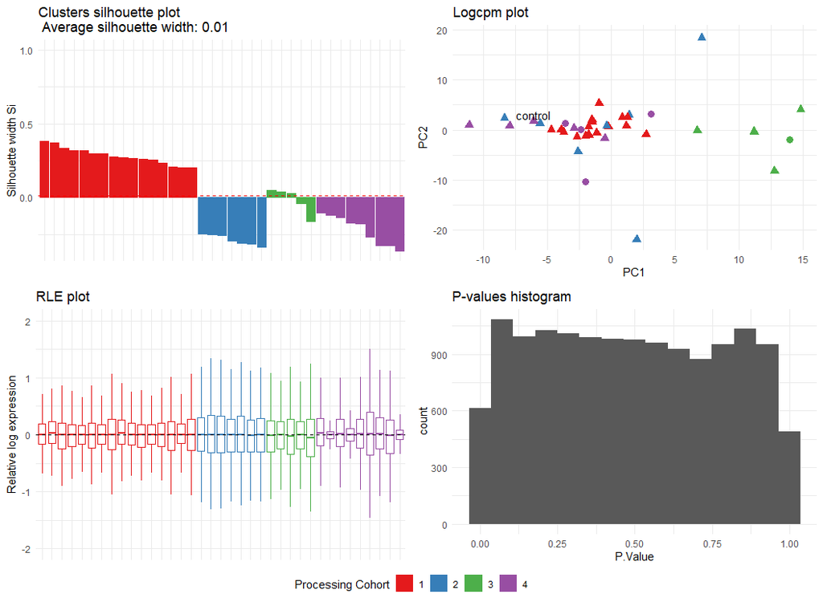

#### cDC

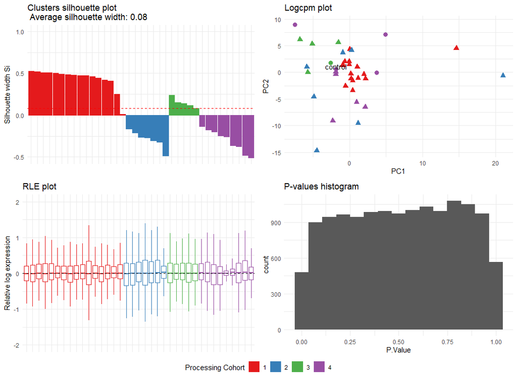

#### cM

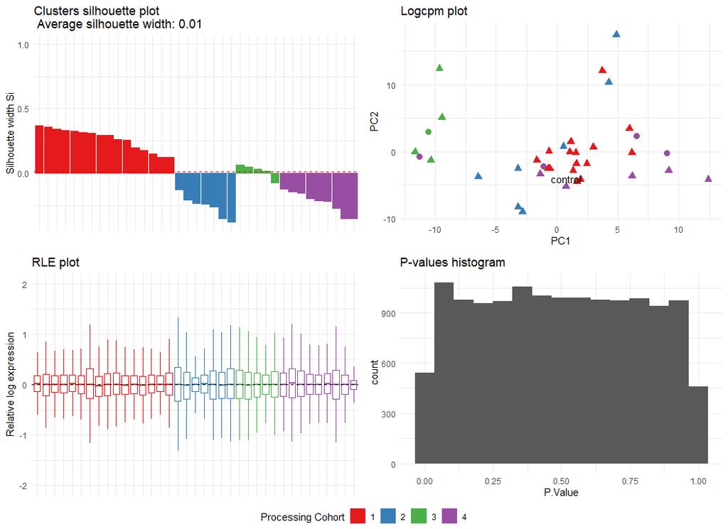

#### ncM

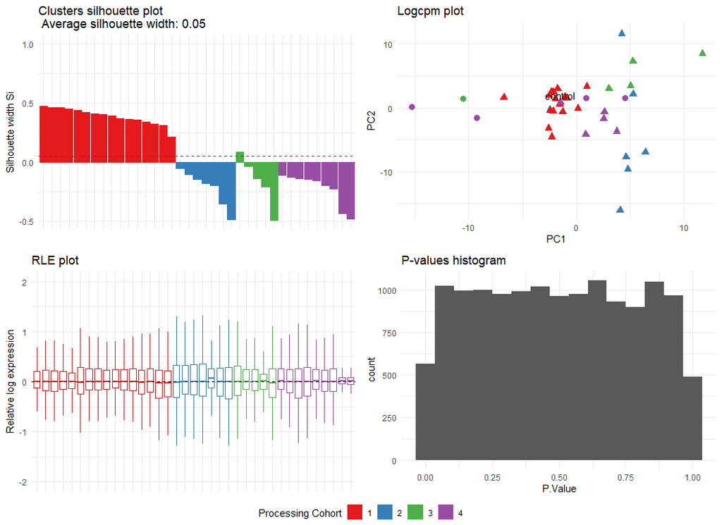

#### pDC

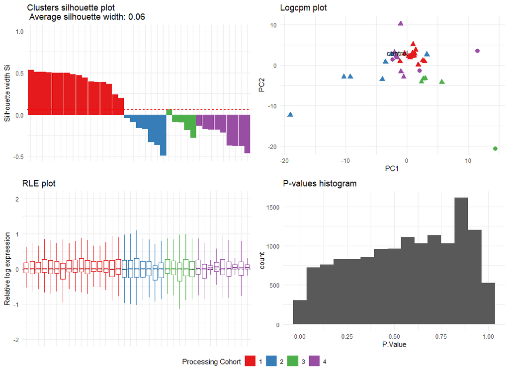

### RUVIII with PBPs

To improve the removal of unwanted technical variation, we extended our analysis by incorporating pseudobulk pseudosamples (PBPS) as described in the PBPS_ISCB vignette. These PBPS were generated and included in the dataset specifically for estimating unwanted factors using the RUVIII method. However, it’s important to note that the pseudosamples were exclusively utilized for calculating the unwanted factors and are not meant to be used in any downstream analyses. They were included in the first PCA plot only for informative purposes. The use of PBPS improves the previous results. Using RUVIII with PBPS led to the lowest average silhouette coefficients, indicating minimal clustering due to batch effects (i.e., processing cohorts), it also resulted in homogeneous distributions in the RLE plots, uniform p-values histogram and a better batch correction in the control sample.

#### B

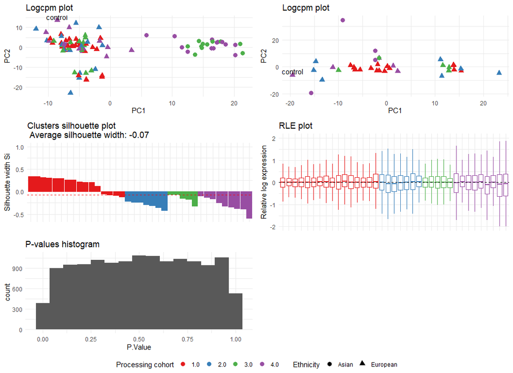

#### NK

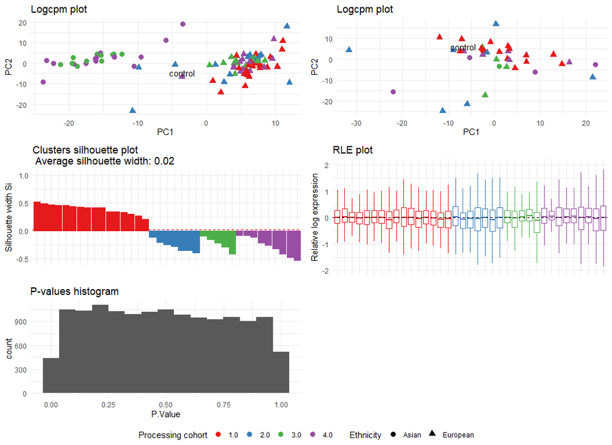

#### T4

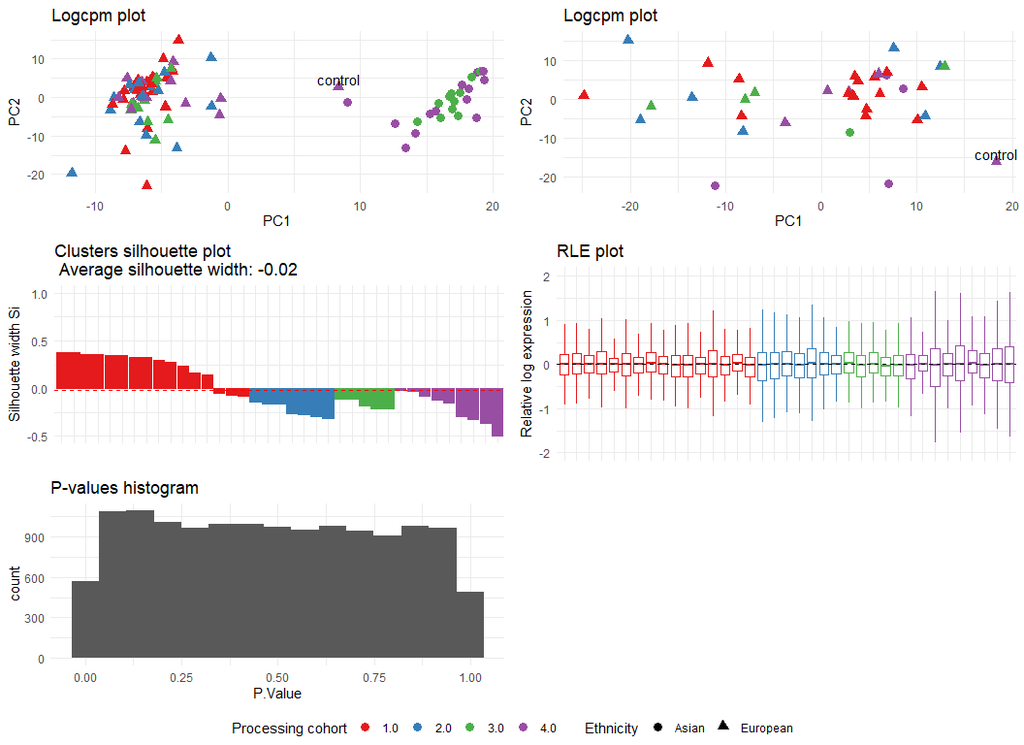

#### T8

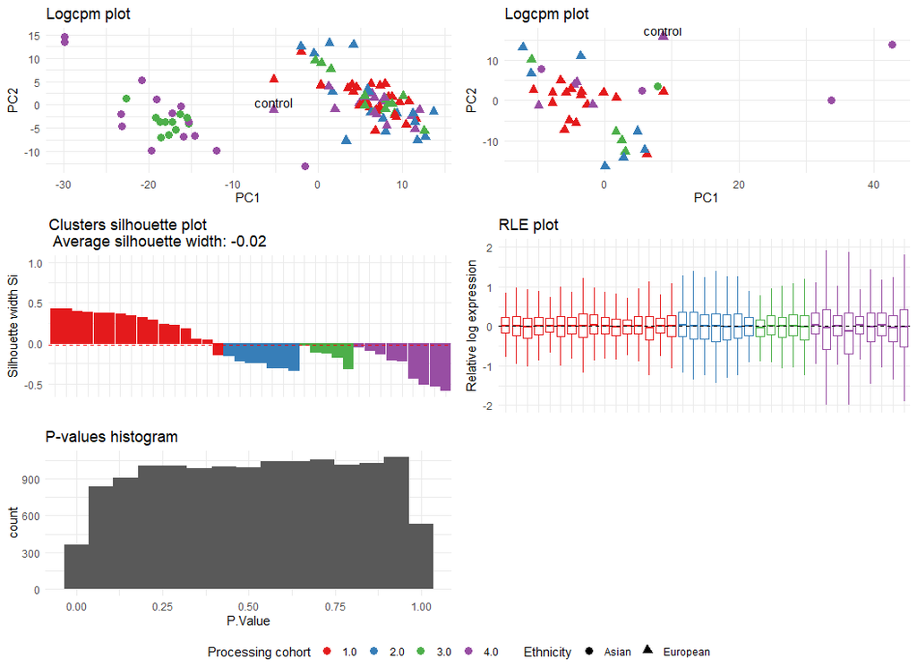

#### cDC

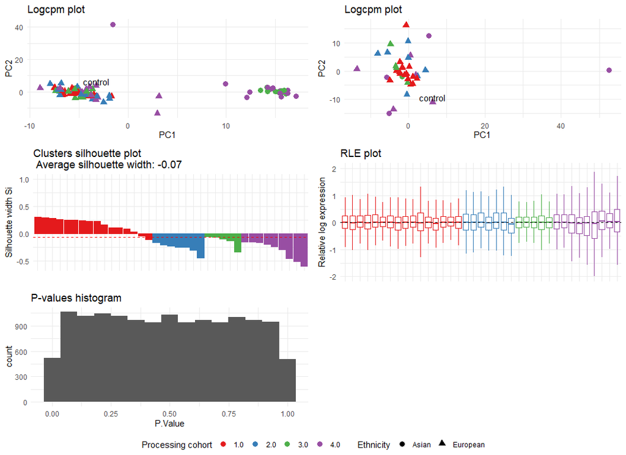

#### cM

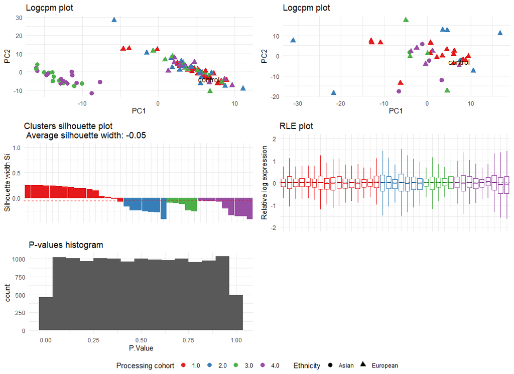

#### ncM

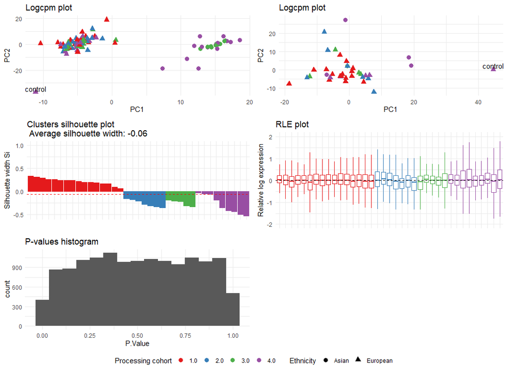

#### pDC

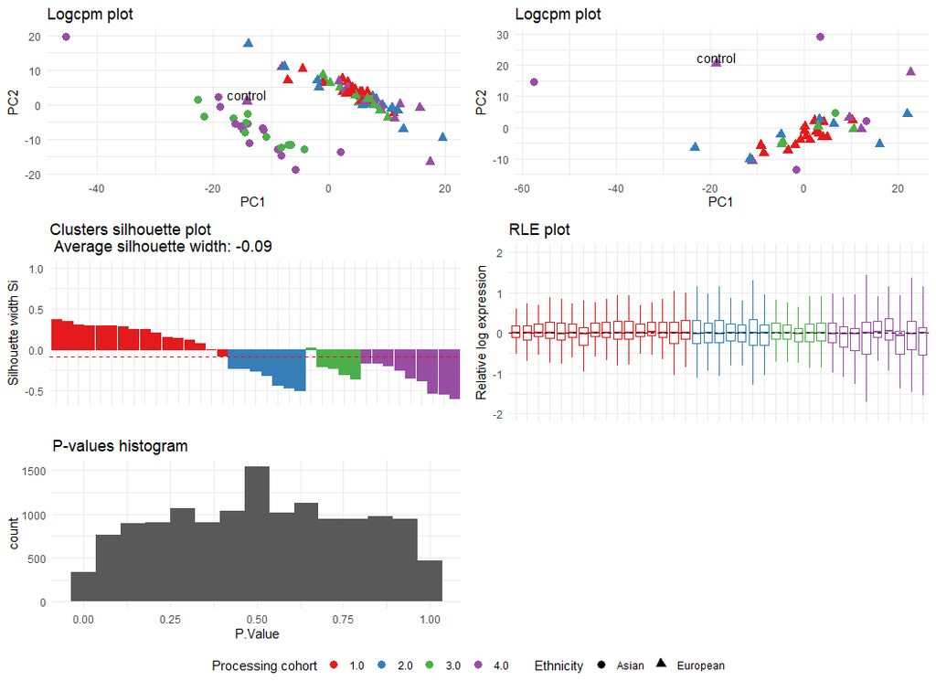